# Assignment 4 H

### K-Means Clustering:

K-Means is a clustering technique which is stochastic in nature whose objective is to group similar data points together by identifying k number of centroids, and then allocate every data point to the nearest cluster, while keeping the centroids as small as possible.

Clustering the data using the K-Means Algorithm.

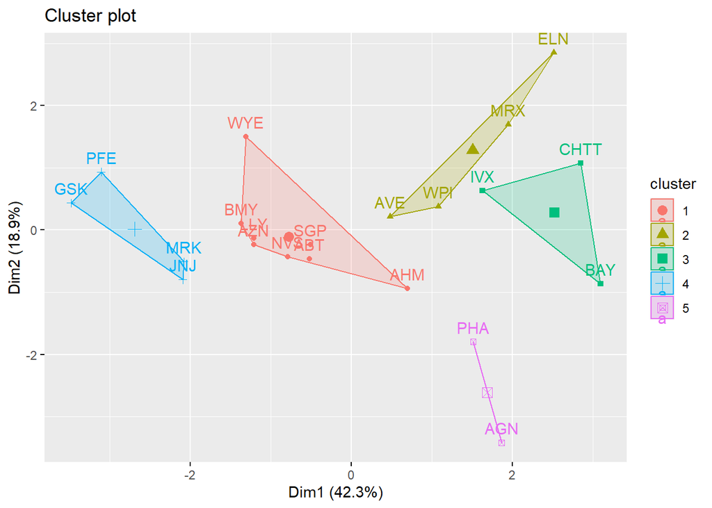

```r
set.seed(2)
Pharma_Kmeans <- kmeans(Pharma_Norm, centers = 5, nstart = 25)
fviz_cluster(Pharma_Kmeans, data = Pharma_Norm)
```

```r
Pharma_Kmeans$centers
```

```
##    Market_Cap       Beta    PE_Ratio        ROE        ROA Asset_Turnover
## 1 -0.03142211 -0.4360989 -0.31724852  0.1950459  0.4083915      0.1729746
## 2 -0.76022489  0.2796041 -0.47742380 -0.7438022 -0.8107428     -1.2684804
## 3 -0.87051511  1.3409869 -0.05284434 -0.6184015 -1.1928478     -0.4612656
## 4  1.69558112 -0.1780563 -0.19845823  1.2349879  1.3503431      1.1531640
## 5 -0.43925134 -0.4701800  2.70002464 -0.8349525 -0.9234951      0.2306328
##      Leverage Rev_Growth Net_Profit_Margin
## 1 -0.27449312 -0.7041516       0.556954446
## 2  0.06308085  1.5180158      -0.006893899
## 3  1.36644699 -0.6912914      -1.320000179
## 4 -0.46807818  0.4671788       0.591242521
## 5 -0.14170336 -0.1168459      -1.416514761
```

```r
Pharma_Kmeans$size
```

```
## [1] 8 4 3 4 2
```

```r
Pharma_Kmeans$withinss
```

```
## [1] 21.879320 12.791257 15.595925  9.284424  2.803505
```

We are applying the k-means technique on the normalized data with k=5.

K-means clustering categorizes the 21 firms into 5 clusters based on similarities across 9 different variables. The optimal value of k=5 leads to a meaningful segmentation of clusters.

In the first cluster, there are 8 companies characterized by moderate market capitalization, efficient asset utilization, and solid profitability. The distance within this cluster is approximately 21.9.

The second cluster comprises 4 companies with very low market capitalization, low returns, and profitability challenges, with a within-cluster distance of approximately 12.8.

Within the third cluster, there are 3 companies with very low market capitalization, high volatility, and struggles in generating returns. The distance within this cluster is approximately 15.6.

The fourth cluster represents 4 companies with high market capitalization, strong returns, and robust profitability, with a within-cluster distance of approximately 9.3.

Finally, the fifth cluster consists of 2 companies with low market capitalization but high valuation, although they encounter difficulties in generating returns. Due to the involvement of only two firms, the within-cluster sum of square distance is very low at 2.8.

### DBSCAN Clustering:

DBSCAN is a density-based clustering algorithm that groups points closely packed together while filtering out noise points in low-density regions. It relies on two parameters: Epsilon, which measures the radius around a data point, and Minimum Points, specifying the minimum number of data points required within the radius of a given point.

Finding the epsilon value.

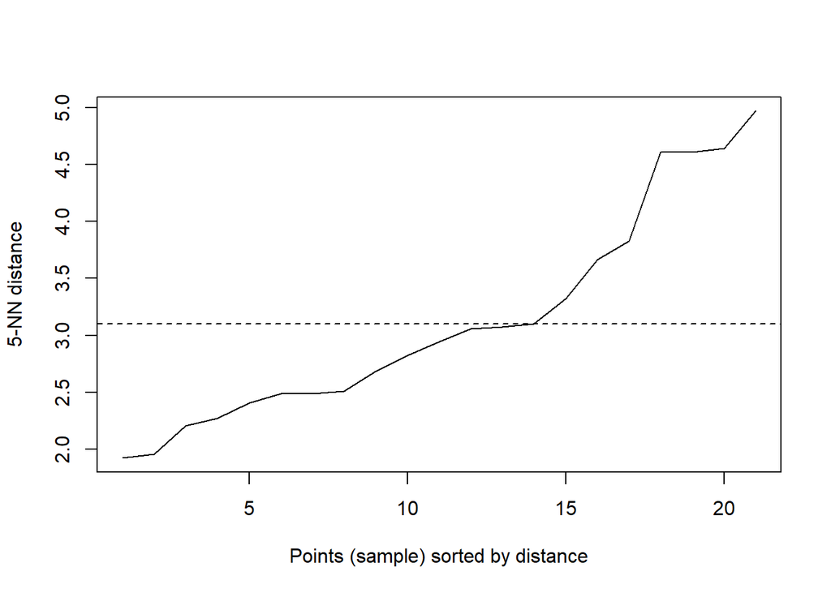

```r
dbscan::kNNdistplot(Pharma_Norm, k=5)
abline(h=3.1, lty=2)
```

According to the plot the optimal epsilon value would be ‘3.1’.

Clustering the data using the DBSCAN Algorithm.

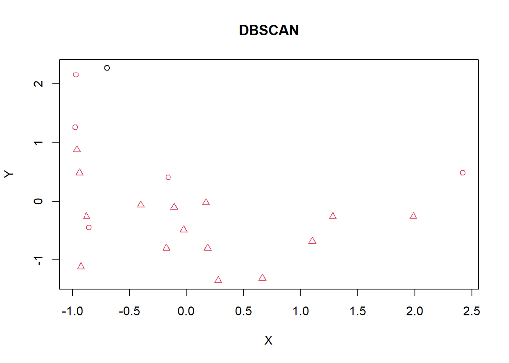

```r
Pharma_DBscan <- fpc::dbscan(Pharma_Norm, eps = 3.1, MinPts = 5)
plot(Pharma_DBscan, Pharma_Norm, main="DBSCAN", frame= TRUE, xlab = "X", ylab = "Y")
```

DBSCAN clustering relies on a minimum density of points to form clusters, which can be challenging with a small dataset like the one provided. Due to the limited number of data points and variables, achieving the required density for meaningful clusters becomes difficult, potentially diluting the similarity between data points. Consequently, the algorithm may struggle to form distinct clusters, as it relies on a certain number of points being close together within a specified radius (epsilon) to form dense clusters. Moreover, DBSCAN considers certain boundary points and noise points by default, which may not be suitable for datasets lacking specific outliers or boundaries. Thus, DBSCAN may not be an appropriate clustering algorithm for the given data.

### Hierarchical Clustering

Hierarchical Clustering creates a hierarchy of clusters in a dataset by initially treating each data point as an individual cluster and then progressively merging the nearest clusters until a predefined criterion is met. This results in a tree-like structure known as a Dendrogram.

Hierarchical clustering can be categorized into two types:

1. Agglomerative Clustering: This approach starts with individual data points as clusters and iteratively merges them together.
2. Divisive Clustering: This approach begins with the entire dataset as a single cluster and iteratively divides it into smaller clusters.

Plotting a Dendrogram using AGNES()

```r
hc_single <- agnes(Pharma_Norm, method = "single")
hc_complete <- agnes(Pharma_Norm, method = "complete")
hc_ward <- agnes(Pharma_Norm, method = "ward")
hc_average <- agnes(Pharma_Norm, method = "average")

print(hc_single$ac)
```

```
## [1] 0.4600348
```

```r
print(hc_complete$ac)
```

```
## [1] 0.6990833
```

```r
print(hc_ward$ac)
```

```
## [1] 0.7943164
```

```r
print(hc_average$ac)
```

```
## [1] 0.5600652
```

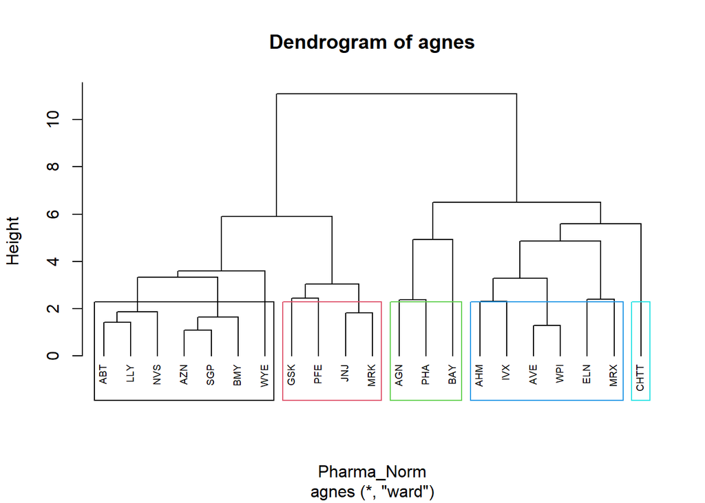

```r
pltree(hc_ward, cex = 0.6, hang = -1, main = "Dendrogram of agnes")
rect.hclust(hc_ward, k=5, border = 1:5)
```

In the process of Hierarchical Clustering, we initially calculate agglomerative coefficients using various methods and select the one returning the highest value, which in this instance is ‘Ward linkage.’ This coefficient indicates the distance between clusters, reflecting their dissimilarity. Analyzing the dendrogram reveals five clusters, with the first comprising 7 firms, the second containing 4 firms, and so on. The last cluster includes only one firm, suggesting potential outliers. However, it’s important to note that outliers may not be applicable to this dataset, where each firm is considered a data point rather than an outlier. Additionally, selecting k as 5 leads to a meaningful cluster division, as clusters are separated based on similar heights, minimizing distances among them and enhancing overall similarity.

Similarly, Divisive Clustering would also identify outliers, making it unsuitable for the given dataset.

### Conclusion:

Among the three clustering algorithms applied, “K-Means” proves most suitable for this dataset. It effectively groups firms with similar characteristics into tighter clusters and is sensitive to outliers and noisy data, yielding meaningful results for a dataset without outliers.

On the other hand, DBSCAN Clustering, by default, considers boundary points and noise points, while the small dataset size poses challenges in forming meaningful clusters. Likewise, Hierarchical Clustering also accounts for outliers, which may not be applicable to this dataset. This clustering algorithm is better suited for datasets where the underlying structure involves natural groupings at different levels of granularity. Hence, both DBSCAN and Hierarchical Clustering might not be as suitable for the given Pharmaceutical dataset.

# 2.(a) Interpret the clusters with respect to the numerical variables used in forming the clusters.

Calculating the centroid and size values for normalized data.

```r
set.seed(2)
Pharma_Kmeans <- kmeans(Pharma_Norm, centers = 5, nstart = 25)
Pharma_Kmeans$centers
```

```
##    Market_Cap       Beta    PE_Ratio        ROE        ROA Asset_Turnover
## 1 -0.03142211 -0.4360989 -0.31724852  0.1950459  0.4083915      0.1729746
## 2 -0.76022489  0.2796041 -0.47742380 -0.7438022 -0.8107428     -1.2684804
## 3 -0.87051511  1.3409869 -0.05284434 -0.6184015 -1.1928478     -0.4612656
## 4  1.69558112 -0.1780563 -0.19845823  1.2349879  1.3503431      1.1531640
## 5 -0.43925134 -0.4701800  2.70002464 -0.8349525 -0.9234951      0.2306328
##      Leverage Rev_Growth Net_Profit_Margin
## 1 -0.27449312 -0.7041516       0.556954446
## 2  0.06308085  1.5180158      -0.006893899
## 3  1.36644699 -0.6912914      -1.320000179
## 4 -0.46807818  0.4671788       0.591242521
## 5 -0.14170336 -0.1168459      -1.416514761
```

```r
Pharma_Kmeans$size
```

```
## [1] 8 4 3 4 2
```

```r
Pharma_Kmeans$withinss
```

```
## [1] 21.879320 12.791257 15.595925  9.284424  2.803505
```

### Conclusion:

After evaluating all the clusters, cluster no-4 appears to be the most ideal as it demonstrates a within-cluster sum of square distance of 9.3 for 4 different firms. Additionally, it shows high market capitalization, strong profitability, and relatively lower risk.

2. Is there a discernible pattern in the clusters with respect to the numerical variables (10 to 12)? (those not used in forming the clusters)

Dropping the first two categorical variables.

```r
set.seed(3)
Pharma_Pattern <- Pharmaceuticals[,-c(1,2)]
head(Pharma_Pattern)
```

```
##   Market_Cap Beta PE_Ratio  ROE  ROA Asset_Turnover Leverage Rev_Growth
## 1      68.44 0.32     24.7 26.4 11.8            0.7     0.42       7.54
## 2       7.58 0.41     82.5 12.9  5.5            0.9     0.60       9.16
## 3       6.30 0.46     20.7 14.9  7.8            0.9     0.27       7.05
## 4      67.63 0.52     21.5 27.4 15.4            0.9     0.00      15.00
## 5      47.16 0.32     20.1 21.8  7.5            0.6     0.34      26.81
## 6      16.90 1.11     27.9  3.9  1.4            0.6     0.00      -3.17
##   Net_Profit_Margin Median_Recommendation Location Exchange
## 1              16.1          Moderate Buy       US     NYSE
## 2               5.5          Moderate Buy   CANADA     NYSE
## 3              11.2            Strong Buy       UK     NYSE
## 4              18.0         Moderate Sell       UK     NYSE
## 5              12.9          Moderate Buy   FRANCE     NYSE
## 6               2.6                  Hold  GERMANY     NYSE
```

Finding the pattern in the clusters with respect to the numerical variables for those not used in forming the clusters.

```r
Cluster_Pattern <-  Pharma_Pattern %>% select(c(10,11,12)) %>% mutate(Cluster = Pharma_Kmeans$cluster)
print(Cluster_Pattern)
```

```
##    Median_Recommendation    Location Exchange Cluster
## 1           Moderate Buy          US     NYSE       1
## 2           Moderate Buy      CANADA     NYSE       5
## 3             Strong Buy          UK     NYSE       1
## 4          Moderate Sell          UK     NYSE       1
## 5           Moderate Buy      FRANCE     NYSE       2
## 6                   Hold     GERMANY     NYSE       3
## 7          Moderate Sell          US     NYSE       1
## 8           Moderate Buy          US   NASDAQ       3
## 9          Moderate Sell     IRELAND     NYSE       2
## 10                  Hold          US     NYSE       1
## 11                  Hold          UK     NYSE       4
## 12                  Hold          US     AMEX       3
## 13          Moderate Buy          US     NYSE       4
## 14          Moderate Buy          US     NYSE       2
## 15                  Hold          US     NYSE       4
## 16                  Hold SWITZERLAND     NYSE       1
## 17          Moderate Buy          US     NYSE       4
## 18                  Hold          US     NYSE       5
## 19                  Hold          US     NYSE       1
## 20         Moderate Sell          US     NYSE       2
## 21                  Hold          US     NYSE       1
```

Visualizing the distribution of firms grouped by clusters by using the bar charts.

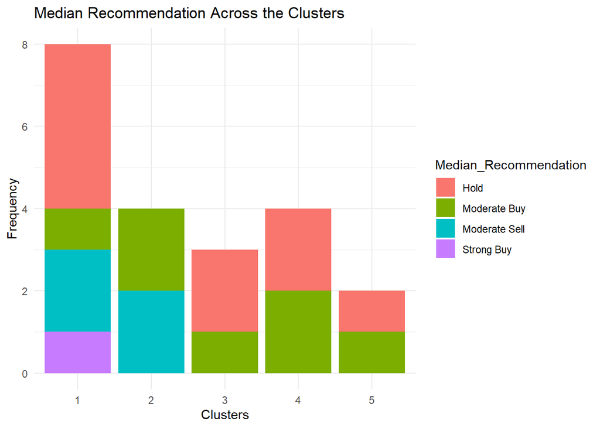

```r
# Bar chart for Median Recommendation
Median_Recommendation <- ggplot(Cluster_Pattern, aes(x = factor(Cluster),
                         fill = Median_Recommendation)) + geom_bar() +
                         labs(x = 'Clusters', y = 'Frequency',
                         title = 'Median Recommendation Across the Clusters') +
                         theme_minimal()
Median_Recommendation
```

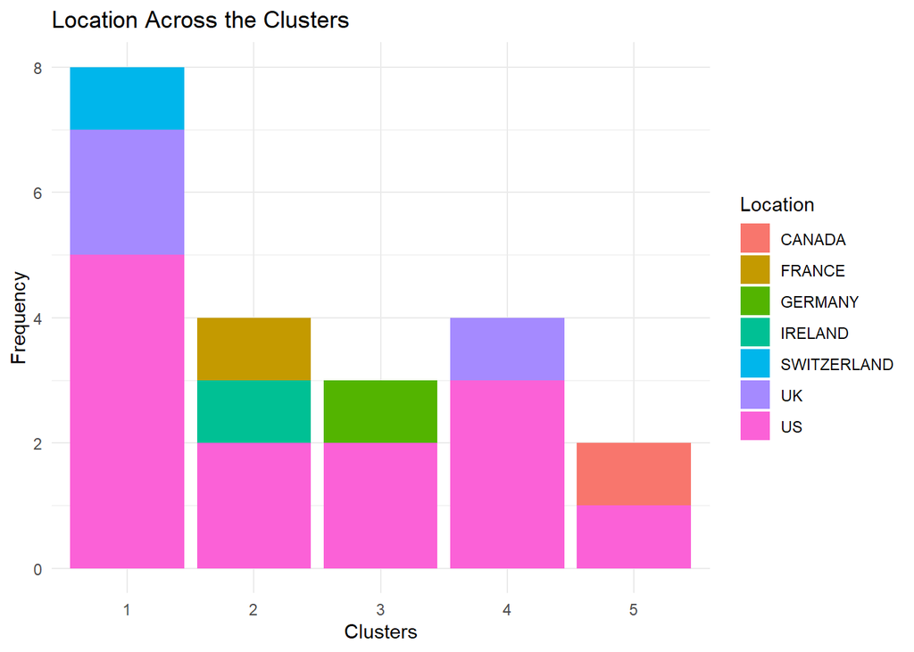

```r
# Bar Chart for Location
Location <- ggplot(Cluster_Pattern, aes(x = factor(Cluster), fill = Location)) +
            geom_bar() + labs(x = 'Clusters', y = 'Frequency',
            title = 'Location Across the Clusters') +
            theme_minimal()
Location
```

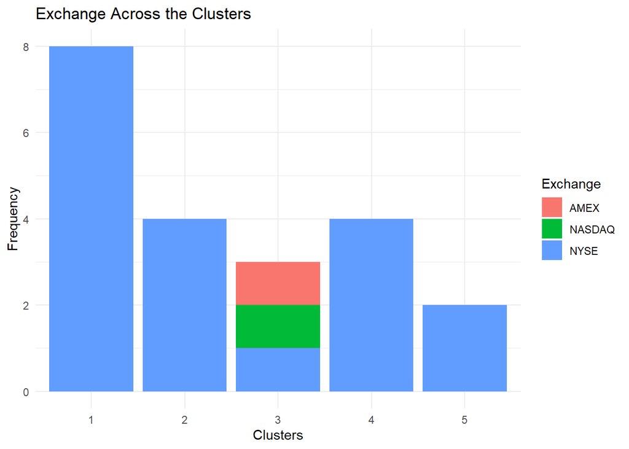

```r
# Bar Chart for Exchange
Exchange <- ggplot(Cluster_Pattern, aes(x = factor(Cluster), fill = Exchange)) +
            geom_bar() + labs(x = 'Clusters', y = 'Frequency',
            title = 'Exchange Across the Clusters') +
            theme_minimal()
Exchange
```

Interpretation of the clusters with respect to categorical variables:

1. Cluster -1 predominantly comprises companies headquartered in the United States, followed by the UK and Switzerland, listed on the New York Stock Exchange (NYSE). Analysts recommend holding their stocks, indicating stability and relatively low-risk investment prospects.
2. Cluster -2 includes companies listed on the NYSE from various locations such as the US, Ireland, and France. Analysts recommend a moderate buy or sell, suggesting potential growth opportunities for these firms.
3. Cluster -3 consists of a mix of American and German companies listed on NYSE, AMEX, and NASDAQ stock exchanges. Analysts recommend holding or moderate buy, indicating a balanced outlook for these companies.
4. Cluster -4 comprises companies from the UK and USA with a mixed recommendation of partially hold and buy for their NYSE-listed stocks. This implies potential growth accompanied by some level of risk.
5. Cluster -5 encompasses a mix of American and Canadian companies listed on the NYSE, with a moderate buy or hold recommendation, indicating both growth potential and some level of risk.

# 3.Provide an appropriate name for each cluster using any or all of the variables in the dataset:

1. Cluster -1 - “Stable Firms”: These companies exhibit balanced financial metrics and operate efficiently within their industry.
2. Cluster -2 - “Growth-Oriented Firms”: Companies with low asset turnover and high revenue growth suggest growth potential but sub-optimal efficiency.
3. Cluster -3 - “High-Risk Firms”: These companies have high leverage, low net profit margin, and ROA, indicating reliance on debt with inadequate profitability and returns, raising investor concerns about meeting debt obligations and potential financial distress.
4. Cluster -4 - “Profitable Firms”: Typically large and well-established companies with significant market presence and a strong financial position. High market capitalization reflects a large number of outstanding shares and a high stock price, resulting in a high valuation. Moderately positive net profit margin indicates stable profitability.
5. Cluster -5 - “Overvalued-Risky Firms”: High PE ratio and low net profit margin suggest the market values the company’s stock at a premium compared to its earnings, despite lower profitability. This poses a risk, as investors paying a premium for each dollar of earnings may lead to future declines in stock price if market expectations are not met.